# ST 495 HW5

Eric Warren

2022-09-23

## Honor Code

I have neither given nor received unauthorized assistance on this test or assignment. -**Eric Warren**

### Problem 1

#### Read in the data

Here we are going to read in the mtcars data.

```r
library(tidyverse)
mtcars <- as_tibble(mtcars)
```

#### Part A

Here we are going to construct a plot of `hp` (x-axis) and `mpg` (y-axis), with different colors for different values of `cyl`.

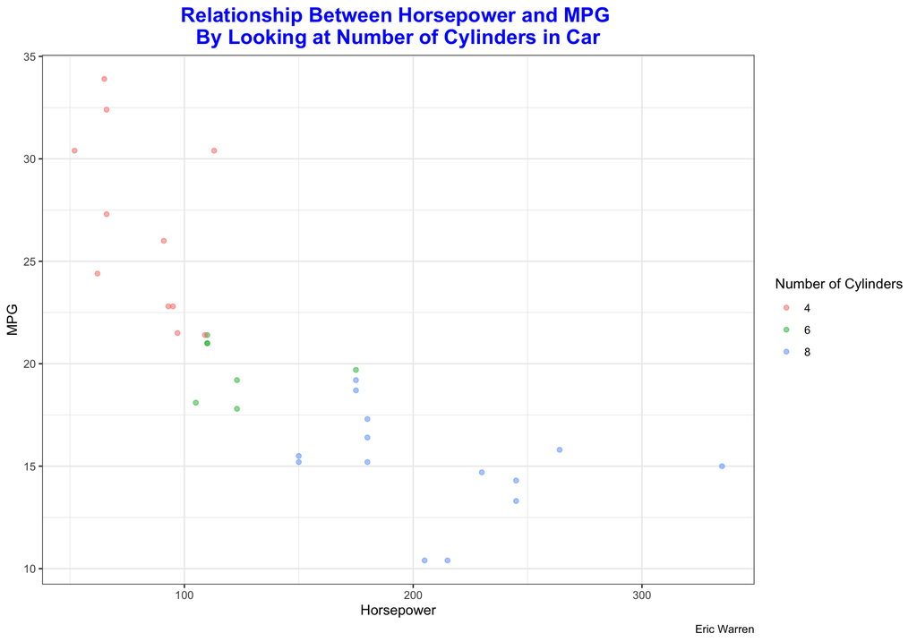

```r
mtcars %>%
  ggplot(aes(x = hp,
             y = mpg,
             color = as_factor(cyl))) +
  geom_point(alpha = 0.5) +
  labs(title = "Relationship Between Horsepower and MPG \nBy Looking at Number of Cylinders in Car",
       caption = "Eric Warren",
       x = "Horsepower",
       y = "MPG",
       color = "Number of Cylinders") +
  theme_bw() +
  theme(plot.title = element_text(color = "blue",
                                  face = "bold",
                                  size = 16,
                                  hjust = 0.5))
```

From looking at this plot, we can see that there is a negative correlation between horsepower and mpg. We can also see that cars with fewer cylinders tend to have less horsepower but are higher in mpg and the reverse is true with cars with more cylinders.

#### Part B

The `am` variable in the *`mtcars`* data set is a factor variable that will only have values of 0 and 1; whereas, if the observation has 0, then it has an automatic transmission versus a value of 1 indicating the car has a manual transmission.

#### Part C

Here we are going to construct a plot of `hp` (x-axis) and `wt` (y-axis), with different colors for different values of `am`.

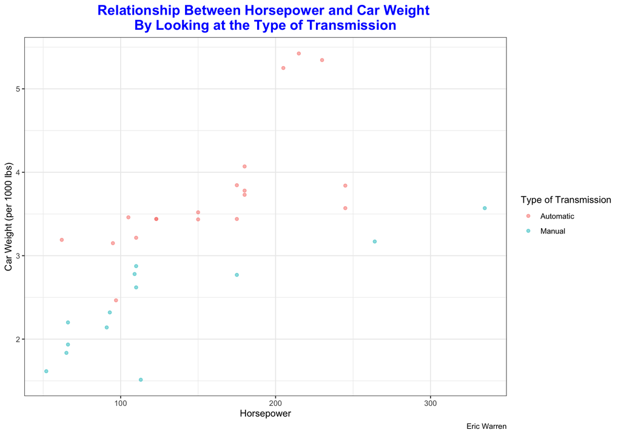

```r
mtcars %>%
  ggplot(aes(x = hp,
             y = wt,
             color = as_factor(am))) +
  geom_point(alpha = 0.5) +
  labs(title = "Relationship Between Horsepower and Car Weight \nBy Looking at the Type of Transmission",
       caption = "Eric Warren",
       x = "Horsepower",
       y = "Car Weight (per 1000 lbs)") +
  scale_color_discrete(name = "Type of Transmission",
                       labels = c("Automatic", "Manual")) +
  theme_bw() +
  theme(plot.title = element_text(color = "blue",
                                  face = "bold",
                                  size = 16,
                                  hjust = 0.5))
```

For the most part we can see a pattern between automatic and manual cars. Automatic cars tend to weigh more as most are above 3,000 pounds and most manual cars are below this threshold. But there are some that do not meet this assumption. Horsepower does not seem to help too much but it looks like a trend shown could be that manual cars have slightly less horsepower compared to automatic cars. The weight of the car should help us a lot more in determining the type of car it is, as only 9.38% of cars do not meet the weight statement of below 3,000 pounds and it is manual or above 3,000 pounds and it is manual.

#### Part D

We are going to fit a logistic regression model with `wt` as the only feature.

```r
am2wtModel <- glm(am ~ wt, mtcars, family = "binomial")
summary(am2wtModel)
```

```
##
## Call:
## glm(formula = am ~ wt, family = "binomial", data = mtcars)
##
## Deviance Residuals:
##      Min        1Q    Median        3Q       Max
## -2.11400  -0.53738  -0.08811   0.26055   2.19931
##
## Coefficients:
##             Estimate Std. Error z value Pr(>|z|)
## (Intercept)   12.040      4.510   2.670  0.00759 **
## wt            -4.024      1.436  -2.801  0.00509 **
## ---
## Signif. codes:  0 '***' 0.001 '**' 0.01 '*' 0.05 '.' 0.1 ' ' 1
##
## (Dispersion parameter for binomial family taken to be 1)
##
##     Null deviance: 43.230  on 31  degrees of freedom
## Residual deviance: 19.176  on 30  degrees of freedom
## AIC: 23.176
##
## Number of Fisher Scoring iterations: 6
```

We can see from this model that heavier cars are more likely to have an automatic transmission (like said in Part C) – also known as less likely to have a manual transmission – because the coefficient of the `wt` variable is negative saying that cars with less weight are manual. If the weight increases by 1000 pounds, the change in odds of a car having a manual transmission is about 0. This is essentially saying that as we add 1000 lbs to the car weight, it is almost certain (or extremely likely) that the car will have an automatic transmission.

#### Part E

We are going to fit a logistic regression model with `hp` as the only feature.

```r
am2hpModel <- glm(am ~ hp, mtcars, family = "binomial")
summary(am2hpModel)
```

```
##
## Call:
## glm(formula = am ~ hp, family = "binomial", data = mtcars)
##
## Deviance Residuals:
##     Min       1Q   Median       3Q      Max
## -1.2955  -0.9968  -0.7818   1.1630   2.0379
##
## Coefficients:
##              Estimate Std. Error z value Pr(>|z|)
## (Intercept)  0.776614   0.915429   0.848    0.396
## hp          -0.008117   0.006074  -1.336    0.181
##
## (Dispersion parameter for binomial family taken to be 1)
##
##     Null deviance: 43.230  on 31  degrees of freedom
## Residual deviance: 41.228  on 30  degrees of freedom
## AIC: 45.228
##
## Number of Fisher Scoring iterations: 4
```

We can see from this model that cars with higher horsepower are more likely to have an automatic transmission (like said in Part C) – also known as less likely to have a manual transmission – because the coefficient of the `hp` variable is negative saying that cars with less horsepower are manual. If the horsepower increases by 100 pounds, the change in odds of a car having a manual transmission is about 0.4441. This is essentially saying that as we add 100 horsepower to the car, it will be about 55.59% less likely that the car will have a manual transmission.

#### Part F

If I had to pick a model that helped predict if a car had a manual or automatic transmission, I would pick the model looking at car weight. As said in Part C, it just looked better on a graph. The big that stands out is that car weight was a significantly significant variable to have an effect on the transmission type. On the flip side, the car horsepower was *NOT* a significantly significant variable to have an effect on the transmission type, so there is a chance that this has no effect on the response variable in question. Thus, I believe it would be better to use the `wt` variable as a predictor of transmission type, and thus the model in Part D is better.

### Problem 2

#### Read in the Data

Here we are going to read in the data.

```r
library(rattle)
data.wine <- as_tibble(wine)
```

Something to check before we do our analysis using our classification techniques is to make sure the variables follow a normal distribution. We are going to make sure here.

```r
# Scale the data
data.wine[ , 2:ncol(data.wine)] <- scale(data.wine[ , 2:ncol(data.wine)])

# Find the means of all the columns to make sure they are zero
apply(data.wine[ , 2:ncol(data.wine)], 2, mean)
```

```
##         Alcohol           Malic             Ash      Alcalinity       Magnesium
##   -8.591766e-16   -6.776446e-17    8.045176e-16   -7.720494e-17   -4.073935e-17
##         Phenols      Flavanoids   Nonflavanoids Proanthocyanins           Color
##   -1.395560e-17    6.958263e-17   -1.042186e-16   -1.221369e-16    3.649376e-17
##             Hue        Dilution         Proline
##    2.093741e-16    3.003459e-16   -1.034429e-16
```

```r
# Find the standard deviations of all columns to make sure they are 1
apply(data.wine[ , 2:ncol(data.wine)], 2, sd)
```

```
##         Alcohol           Malic             Ash      Alcalinity       Magnesium
##               1               1               1               1               1
##         Phenols      Flavanoids   Nonflavanoids Proanthocyanins           Color
##               1               1               1               1               1
##             Hue        Dilution         Proline
##               1               1               1
```

#### Part A

Here we are going to perform classification using LDA (linear discriminant analysis) and report the classification error rate.

```r
data.wine <- as_tibble(wine)
library(MASS)
set.seed(9)
trainpct = 0.7
n = nrow(data.wine)
sample <- sample(1:n, round(n * trainpct))
train <- data.wine[sample, ]
test <- data.wine[-sample, ]

ldaModel <- lda(Type ~ ., train)
ldaModel
```

```
## Call:
## lda(Type ~ ., data = train)
##
## Prior probabilities of groups:
##     1     2     3
## 0.344 0.344 0.312
##
## Group means:
##    Alcohol    Malic      Ash Alcalinity Magnesium  Phenols Flavanoids
## 1 13.78884 1.993953 2.472326   16.87674 106.76744 2.890698   3.035116
## 2 12.21814 2.044651 2.243023   20.16047  92.34884 2.194419   1.992326
## 3 13.21179 3.380000 2.436410   21.56410 100.10256 1.689487   0.805641
##   Nonflavanoids Proanthocyanins    Color       Hue Dilution   Proline
## 1     0.3000000        1.930000 5.503256 1.0630233 3.129070 1107.4884
## 2     0.3700000        1.596977 2.949535 1.0522326 2.767442  503.9302
## 3     0.4328205        1.188462 7.483333 0.6787179 1.690256  623.9744
##
## Coefficients of linear discriminants:
##                          LD1          LD2
## Alcohol         -0.274418851  1.286734941
## Malic            0.161664072  0.211333912
## Ash             -0.025170123  1.989399714
## Alcalinity       0.103922738 -0.102411134
## Magnesium       -0.001893942  0.009553067
## Phenols          0.726507613  0.056670475
## Flavanoids      -2.243015811 -0.400980344
## Nonflavanoids   -2.127652967 -1.798562055
## Proanthocyanins  0.370911328 -0.430351140
## Color            0.322113692  0.136067454
## Hue             -1.128439378 -1.648371737
## Dilution        -1.266357776 -0.179819065
## Proline         -0.002741015  0.002708541
##
## Proportion of trace:
##    LD1    LD2
## 0.7469 0.2531
```

```r
pred.lda <- predict(ldaModel, test)
table.lda <- table(predicted = test$Type, observed = pred.lda$class)
accuracyTable.lda <- caret::confusionMatrix(table.lda)
accuracyTable.lda
```

```
## Confusion Matrix and Statistics
##
##          observed
## predicted  1  2  3
##         1 16  0  0
##         2  2 25  1
##         3  0  0  9
##
## Overall Statistics
##
##                Accuracy : 0.9434
##                  95% CI : (0.8434, 0.9882)
##     No Information Rate : 0.4717
##     P-Value [Acc > NIR] : 1.756e-13
##
##                   Kappa : 0.9081
##
##  Mcnemar's Test P-Value : NA
##
## Statistics by Class:
##
##                      Class: 1 Class: 2 Class: 3
## Sensitivity            0.8889   1.0000   0.9000
## Specificity            1.0000   0.8929   1.0000
## Pos Pred Value         1.0000   0.8929   1.0000
## Neg Pred Value         0.9459   1.0000   0.9773
## Prevalence             0.3396   0.4717   0.1887
## Detection Rate         0.3019   0.4717   0.1698
## Detection Prevalence   0.3019   0.5283   0.1698
## Balanced Accuracy      0.9444   0.9464   0.9500
```

```r
accuracyTable.lda$overall[[1]] # Returns the accuracy of the model
```

```
## [1] 0.9433962
```

After doing Linear Discriminant Analysis, this modeling technique was used to predict the `Type` of wine something is. Using cross validation, it is shown that this model has an accuracy of 94.34% or also known as a classification error of 5.66%. It is remarkable that this technique could do a pretty good job in predicting the type of wine using all the predictors, as it got 3 out of our 53 test data observations wrong.

#### Part B

Here we are going to perform classification using QDA (quadratic discriminant analysis) and report the classification error rate.

```r
qdaModel <- qda(Type ~ ., train)
qdaModel
```

```
## Call:
## qda(Type ~ ., data = train)
##
## Prior probabilities of groups:
##     1     2     3
## 0.344 0.344 0.312
##
## Group means:
##    Alcohol    Malic      Ash Alcalinity Magnesium  Phenols Flavanoids
## 1 13.78884 1.993953 2.472326   16.87674 106.76744 2.890698   3.035116
## 2 12.21814 2.044651 2.243023   20.16047  92.34884 2.194419   1.992326
## 3 13.21179 3.380000 2.436410   21.56410 100.10256 1.689487   0.805641
##   Nonflavanoids Proanthocyanins    Color       Hue Dilution   Proline
## 1     0.3000000        1.930000 5.503256 1.0630233 3.129070 1107.4884
## 2     0.3700000        1.596977 2.949535 1.0522326 2.767442  503.9302
## 3     0.4328205        1.188462 7.483333 0.6787179 1.690256  623.9744
```

```r
pred.qda <- predict(qdaModel, test)
table.qda <- table(predicted = test$Type, observed = pred.qda$class)
accuracyTable.qda <- caret::confusionMatrix(table.qda)
accuracyTable.qda
```

```
## Confusion Matrix and Statistics
##
##          observed
## predicted  1  2  3
##         1 16  0  0
##         2  1 27  0
##         3  0  0  9
##
## Overall Statistics
##
##                Accuracy : 0.9811
##                  95% CI : (0.8993, 0.9995)
##     No Information Rate : 0.5094
##     P-Value [Acc > NIR] : 1.556e-14
##
##                   Kappa : 0.9688
##
##  Mcnemar's Test P-Value : NA
##
## Statistics by Class:
##
##                      Class: 1 Class: 2 Class: 3
## Sensitivity            0.9412   1.0000   1.0000
## Specificity            1.0000   0.9615   1.0000
## Pos Pred Value         1.0000   0.9643   1.0000
## Neg Pred Value         0.9730   1.0000   1.0000
## Prevalence             0.3208   0.5094   0.1698
## Detection Rate         0.3019   0.5094   0.1698
## Detection Prevalence   0.3019   0.5283   0.1698
## Balanced Accuracy      0.9706   0.9808   1.0000
```

```r
accuracyTable.qda$overall[[1]] # Returns the error
```

```
## [1] 0.9811321
```

After doing Quadratic Discriminant Analysis, this modeling technique was used to predict the `Type` of wine something is. Using cross validation, it is shown that this model has an accuracy of 98.11% or also known as a classification error of 1.89%. It is extremely remarkable that this technique could predict very well the type of wine using all the predictors, as it got only 1 out of our 53 test data observations wrong, which is better than using Linear Discriminant Analysis.

#### Part C

Here we are going to perform classification using NB (Naive Bayes) and report the classification error rate.

```r
library(e1071)
nbModel <- naiveBayes(Type ~ ., train)
nbModel
```

```
##
## Naive Bayes Classifier for Discrete Predictors
##
## Call:
## naiveBayes.default(x = X, y = Y, laplace = laplace)
##
## A-priori probabilities:
## Y
##     1     2     3
## 0.344 0.344 0.312
##
## Conditional probabilities:
##    Alcohol
## Y       [,1]      [,2]
##   1 13.78884 0.4655115
##   2 12.21814 0.4156077
##   3 13.21179 0.5348629
##
##    Malic
## Y       [,1]      [,2]
##   1 1.993953 0.6580134
##   2 2.044651 1.1234923
##   3 3.380000 1.1637847
##
##    Ash
## Y       [,1]      [,2]
##   1 2.472326 0.2356029
##   2 2.243023 0.2923023
##   3 2.436410 0.1892852
##
##    Alcalinity
## Y       [,1]     [,2]
##   1 16.87674 2.665551
##   2 20.16047 3.285186
##   3 21.56410 2.192029
##
##    Magnesium
## Y        [,1]     [,2]
##   1 106.76744 10.84487
##   2  92.34884 14.37737
```

[output cut: 34 more lines]

```
##   1 1.0630233 0.1189545
##   2 1.0522326 0.2001500
##   3 0.6787179 0.1117841
##
##    Dilution
## Y       [,1]      [,2]
##   1 3.129070 0.3833425
##   2 2.767442 0.4898352
##   3 1.690256 0.2703262
##
##    Proline
## Y        [,1]     [,2]
##   1 1107.4884 220.5417
##   2  503.9302 157.0410
##   3  623.9744 115.2753
```

```r
pred.nb <- predict(nbModel, test)
table.nb <- table(predicted = test$Type, observed = pred.nb)
accuracyTable.nb <- caret::confusionMatrix(table.nb)
accuracyTable.nb
```

```
## Confusion Matrix and Statistics
##
##          observed
## predicted  1  2  3
##         1 16  0  0
##         2  3 23  2
##         3  0  0  9
##
## Overall Statistics
##
##                Accuracy : 0.9057
##                  95% CI : (0.7934, 0.9687)
##     No Information Rate : 0.434
##     P-Value [Acc > NIR] : 7.153e-13
##
##                   Kappa : 0.8496
##
##  Mcnemar's Test P-Value : NA
##
## Statistics by Class:
##
##                      Class: 1 Class: 2 Class: 3
## Sensitivity            0.8421   1.0000   0.8182
## Specificity            1.0000   0.8333   1.0000
## Pos Pred Value         1.0000   0.8214   1.0000
## Neg Pred Value         0.9189   1.0000   0.9545
## Prevalence             0.3585   0.4340   0.2075
## Detection Rate         0.3019   0.4340   0.1698
## Detection Prevalence   0.3019   0.5283   0.1698
## Balanced Accuracy      0.9211   0.9167   0.9091
```

```r
accuracyTable.nb$overall[[1]]
```

```
## [1] 0.9056604
```

After doing Naive Bayes, this modeling technique was used to predict the `Type` of wine something is. Using cross validation, it is shown that this model has an accuracy of 90.57% or also known as a classification error of 9.43%. It is remarkable that this technique could predict very well the type of wine using all the predictors, as it got only 5 out of our 53 test data observations wrong, which is not as good as Linear Discriminant Analysis and Quadratic Discriminant Analysis.

#### Part D

Here I am going to rank what I think the best classification models are to use for this data.

First, let us look at the classification errors.

```r
`Classification Name` <- c("LDA", "QDA", "Naive Bayes")
Accuracy <- round(c(accuracyTable.lda$overall[[1]], accuracyTable.qda$overall[[1]], accuracyTable.nb$overall[[1]]), 4)
tableOfErrors <- as_tibble(cbind(`Classification Name`, Accuracy))
knitr::kable(tableOfErrors, "pipe")
```

| Classification Name | Accuracy |
| --- | --- |
| LDA | 0.9434 |
| QDA | 0.9811 |
| Naive Bayes | 0.9057 |

Since it is down to QDA or LDA for which one the best model is and the errors are so close (despite QDA seeming like the better model with the lower error), we should look at the covariance matrix. For LDA the covariance needs to essentially be equal for each variable in the data set, while for QDA it does not have to be. We are going to do a statistical test on this.

```r
covTest <- heplots::boxM(data.wine[ , 2:ncol(data.wine)], data.wine$Type)
covTest
```

```
##
##  Box's M-test for Homogeneity of Covariance Matrices
##
## data:  data.wine[, 2:ncol(data.wine)]
## Chi-Sq (approx.) = 684.2, df = 182, p-value < 2.2e-16
```

So because there is statistically significant evidence to conclude that the covariance is not equal across the variables, we can say that it would be better to use QDA over LDA for this reason, which reaffirms our initial hunch since the classification error rate was slightly lower for QDA.

So in conclusion, my rankings from best to worst would be:

1. QDA Classification Model
2. LDA Classification Model
3. Naive Bayes Classification Model